# {workr} — PHUSE SDE 2026

A very simple R data pipeline · Foster City, CA · 30-min talk

Zelos Zhu + Jeremy Wildfire

2026-08-06

Most data pipelines are an ordered list of function calls.

{workr} takes that literally.

## The model

- A **workflow** is a YAML list of function calls
- **`lData`** flows through every step and is updated as it goes
- **`workr::RunWorkflow()`** runs the list and returns the last result

## A complete pipeline

```yaml
# hello_cars.yaml
meta:
  ID: hello_cars
  col: speed
steps:
  - name: get                 # load a dataset
    output: df                # -> lData$df
    params:
      x: "cars"
  - name: dplyr::pull         # pull one column
    output: speed             # -> lData$speed
    params:
      .data: df
      var: col                # meta$col == "speed"
  - name: mean                # summarize it
    output: result            # -> lData$result
    params:
      x: speed
```

## Configuration, not code

[figure not shown]

[figure not shown]

Scan to run the pipeline yourself — [zeloszhu.com/workr_demoapp](https://zeloszhu.com/workr_demoapp/)

# Does this scale?

## The reason {workr} exists

30 studies × monthly snapshots × 15 metrics × 5 steps

≈ 27,000 metrics / year

…each one regulated, GxP output. Study designs vary, so metrics need per-study tweaks — a hand-written script per study didn’t hold up.

## A real metric is the same shape

```yaml
meta:
  ID: kri0001
  Metric: Adverse Event Rate
  Numerator: Adverse Events
  Denominator: Days on Study
  Model: Normal Approximation
  Threshold: -2,-1,2,3
steps:
  - name: gsm.core::ParseThreshold   # ...
  - name: gsm.core::Input_Rate       # numerator / denominator
  - name: gsm.core::Transform_Rate
  - name: gsm.core::Analyze_NormalApprox
  - name: gsm.core::Flag             # apply thresholds
  - name: gsm.core::Summarize
```

Real KRI from `{gsm}` — `gsm.kri/inst/workflow/2_metrics/kri0001.yaml` (params trimmed to fit).

## One report — every metric, every site

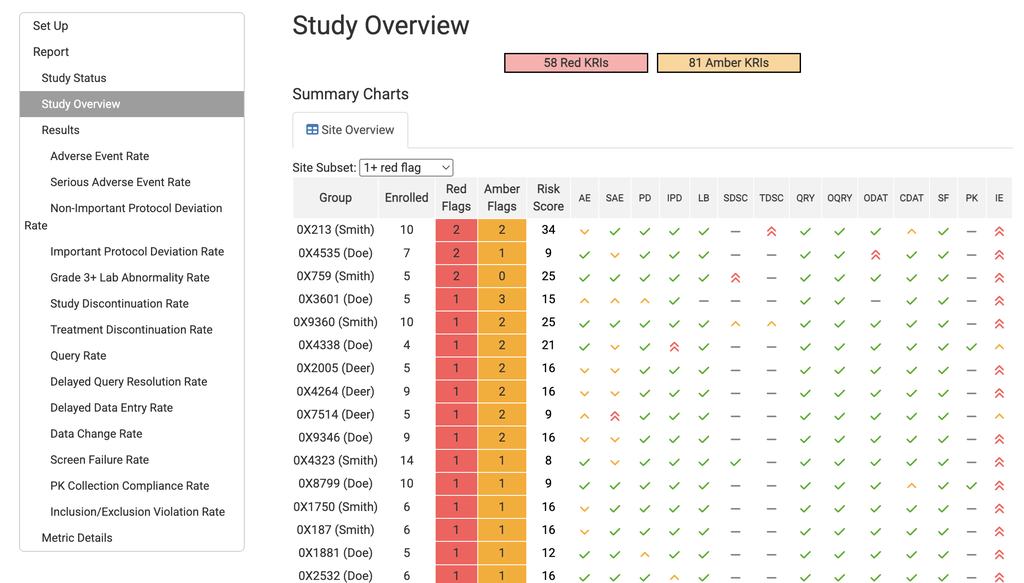

Each column (AE, SAE, PD, LB, …) is a workflow like the last slide. Every site. Every month.

## …and across the whole portfolio

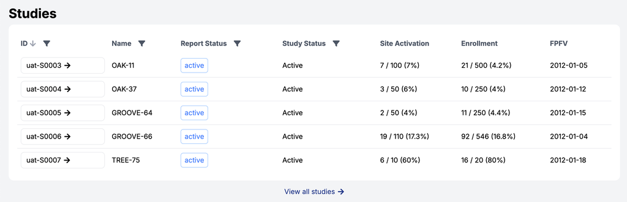

Same framework, many studies — now running on 20+ studies in production.

## Qualify the framework once

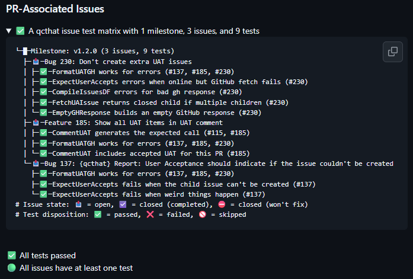

[{qcthat}](https://github.com/Gilead-Public/qcthat) links requirements to tests — qualify one framework, not 27,000 scripts.

# The same approach across {pharmaverse}

not only clinical operations

## One pattern, the whole clinical stack

**RAW** → **SDTM** → **ADaM** → **TFL / ARD**

`{sdtm.oak}` · `{admiral}` · `{rmarkdown}` · `{cards}`

## A step is a function call

Workflow step

```yaml
steps:
  - output: vs_raw
    name: sdtm.oak::generate_oak_id_vars
    params:
      raw_dat: vs_raw
      pat_var: "PATNUM"
      raw_src: "vitals"
```

=

Plain R

```r
vs_raw <-
  generate_oak_id_vars(
    raw_dat = vs_raw,
    pat_var = "PATNUM",
    raw_src = "vitals"
  )
```

Adopting a package is mostly about knowing that package, not learning {workr}.

## The rest of the stack follows the same form

| Stage | Package | A representative step |
| --- | --- | --- |
| SDTM → ADaM | `{admiral}` | `admiral::derive_param_map()` → MAP from SYSBP/DIABP |
| ADaM → TFL | `{rmarkdown}` | `rmarkdown::render()` a parameterized template |
| ADaM → ARD | `{cards}` | `cards::ard_summary()` for CDISC Analysis Results Data |

`!expr` carries quasiquotation (`exprs()`, `!!`) directly into a step’s params.

## Example: an ARD in two steps

```yaml
steps:
  - output: predose_visit1_map
    name: workr::RunQuery        # SQL over a data.frame
    params:
      df: ADVS
      strQuery: >
        SELECT * FROM df
        WHERE PARAMCD = 'MAP'
          AND VISIT = 'VISIT1'
          AND VSTPT = 'PREDOSE'
  - output: table_predose_visit1_map
    name: cards::ard_summary     # CDISC Analysis Results Data
    params:
      data: predose_visit1_map
      variables:
        - AVAL
```

Verbatim from `demo_gsmpharmaverse/workflows/3_ADAM_TO_ARS/table_mean_arterial_pressure.yaml`.

## Where it lands is your call

- Workflows orchestrate transformation; saving is deliberately decoupled
- Writing to csv / parquet / json / a data lake is another step
- The same workflow can feed a Shiny app, a static site, or a PDF over email

# A side effect: it works well with AI

a workflow is data, not code

## Agents can read and write workflows

**Read**

- Explain a workflow step by step
- Diff two runs and locate the change
- Debug a failure in plain language

**Write**

- Draft a new workflow from a request
- Add or reorder steps safely
- {gsm} + {workr} skills coming soon

The properties that make a workflow auditable also make it legible to a model.

## Seen this talk before? What changed in 1.1.0

**Then (1.0)**

- `RunWorkflow()` / `RunWorkflows()`
- Point them at a folder of YAML
- Storage wired into your own script

**New in 1.1.0**

- `RunProject()` — multi-phase runs
- Load/save **hooks** — storage decoupled
- Workflow **discovery** — active/inactive, priority, exact-name

The model is unchanged. What’s new is running it as a real, scheduled, restartable production pipeline.

## New: `RunProject()` runs phases in order

```r
# project/
#   01_mapping/
#   02_analysis/
#   03_reporting/
workr::RunProject(
  strPath = "project",
  bContinueOnError = TRUE
)
```

Each subfolder is a **phase**; outputs carry forward to the next.

```yaml
# 03_reporting/_config.yaml
input:
  from_phases: [01_mapping]
  from_results:
    lAnalyzed: 02_analysis
output:
  wrap_as: lReports
```

A `_config.yaml` shapes exactly what each phase receives and exposes.

`bContinueOnError` records failures and keeps going — restartable, multi-phase runs.

## New: storage is a hook, not a rewrite

```r
workr::RunWorkflow(
  lWorkflow = wf,
  lConfig = list(LoadData = "gsm.datasim")   # a registered provider, by name
)

workr::register_save_provider("github_artifact", my_saver)  # or bring your own
```

- Built-in **GitHub Actions artifact** providers pass data between runs
- Same workflow, different storage — no change to the steps

Live walkthrough of all of this: [zeloszhu.com/workr_demoapp](https://zeloszhu.com/workr_demoapp/) · [source](https://github.com/zdz2101/workr_demoapp)

# Thank you

Simple, scalable, GxP-ready, open source

[gilead-public.github.io/workr](https://gilead-public.github.io/workr/)

Try the live demo → [zeloszhu.com/workr_demoapp](https://zeloszhu.com/workr_demoapp/)

[figure not shown]